# Linking climate drivers to vital rates

11/11/2021

### Introduction

Hi there! Today we’re going to have a detailed look at the survival probability of *Cylindriopuntia imbricata*, and how three different climate drivers influence this survival probability. This tutorial should walk you through every step, but feel free to ask us if you get stuck.

You’ll find all the data you need on github (where you also found this document hopefully!)  
https://github.com/SanneE1/Lab-5-linking-VR-to-CD

Today we will:  
1. Dataset: load and filter the biological data  
2. Exploring survival: explore the survival vital rate through plots  
3. Base model: run the base model for survival without climate drivers  
4. Climate: load and format the climate data 5. Select climate driver: add climate drivers to the base model and select the best option

## Dataset

Let’s start with the basics, before you start, please install/load the packages `dplyr`, `lme4`, `bbmle`, `testthat` and if you prefer `ggplot` over base `R` go right ahead. Next we load in the biological data. This data has already been formatted for the most part. Let’s have a quick look shall we?

> Please load the file 'OPIM_indiv_data.csv' into R

There are 8 columns in the file.  
* `plantID` = A unique code for each individual plant.  
* `Plot` = Observations were done across several different plots.  
* `yearT` = The year the observations were done.  
* `sizeT` = The size of the individual in yearT. This size was calculated as the log transformed volume of a cone, using plant height, maximum width, and the width perpendicular to the maximum width.  
* `pflower` = Did the individual flower in year T (0/1).  
* `fertilityT` = The number of flowers in year T.  
* `survival` = Did the individual survive from yearT to the next year (yearT1).  
* `sizeT1` = The size of the individual in the next year (yearT1).

Now we’ll need to filter out some observations that are not useful for us.

> There are some rows, where there is no sizeT. These are either mistakes or seedlings/new individuals. Please select only entries that have a sizeT.

**Hint**

```r
# one option is to use the filter() function from dplyr
```

**Hint**

```r
# As selection criteria, we want everything that is not NA.
# The function is.na() selects everything that is NA.
# In R, if you put a ! in front of an is question (is equal to, is NA, etc.) you change your question from "is", to "is not"

dplyr::filter(..., !is.na(sizeT))
```

> We also know from the people that gathered data, that the transition from 2018-2019 (T to T1) had some problems, so please filter out this year.

**Hint**

```r
# dplyr option: use %>% filter()

# base option: try df[which(),]
```

## Exploring survival

For the next part, we will focus on survival probability. Before we can start exploring this vital rate, and see how we’re going to model it, we need to make sure that we have data that only includes entries where we have information.

> Select only those entries where there are 0’s or 1’s in the `survival` column

**Hint**

```r
# if there's no 0 or 1 in the column it contains NA, so filter out all entries with NA and you're good!
```

When modelling survival we usually assume it is dependent on a state variable. In this case we have `sizeT` as our state variable. Moreover, we try to use a logistic regression.

> Please plot the `survival` vs `sizeT`

It should look a bit like this:

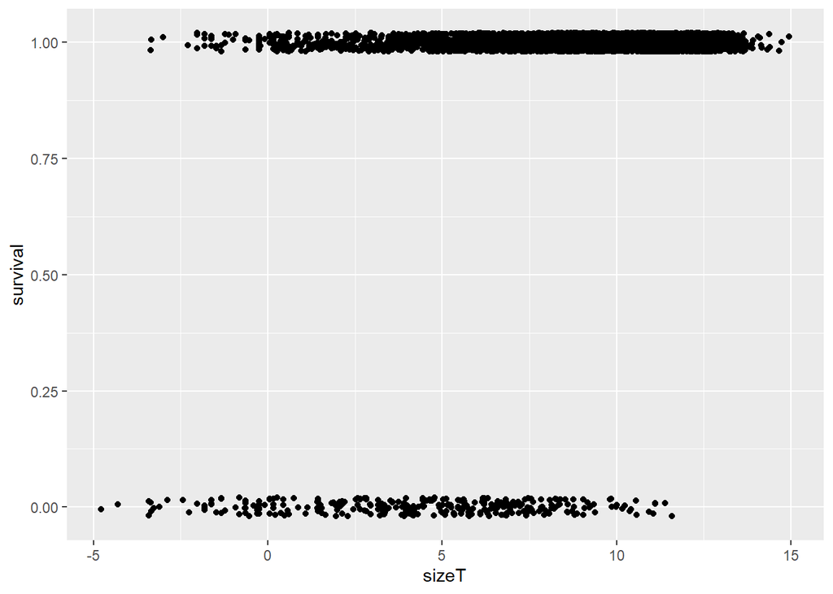

It looks like there’s a higher probability of surviving, with increasing size. But because there’s only 0 and 1’s, it makes it a bit harder to see. Which is why we need a model to confirm!

## Base model

Before we can start looking at which climate driver best predicts the survival probability, we need to find a base model that we use for the comparisons. The better our base model is the better our predictions will be!

We have survival as the response variable (y variable) and the graphs show we can pretty confidently assume that survival is dependent on sizeT (x variable).

The next question we need to answer is if we can use a linear model, or if we need a generalized linear model. Survival is a binomial variable (0/1’s). This actually answers the question already; we have a binomial distribution, and so we need to use a generalized linear model.

> Have a look at the columns in the individual data. What columns other than `sizeT` could be variables that influence survival?

**Hint**

```r
# The dataframe includes 3 columns with information on other vital rates (flower probability, flower numbers and size in the next year). We assume for now that these vital rates do not have an effect on survival probability
```

**Hint**

```r
# The remaining columns are plantID, Plot, and yearT.
# individual plants could be better at surviving than others (because of location, genetics etc.)
# individuals in different plots could have different survival probabilities, because the plot is located in a dryer/wetter location, more/less trampling by people/grazers etc.
# year could also have an effect. Even though we are trying to include a climate driver later on, we won't be able to include all the differences from one year to the next. Including year will therefore form a sort of grouping variable for everything that changes from year to year, that we are not modelling
```

Below are two different linear functions. The first model only has a fixed effect, while the second only has a random effect.

```r
# Option 1:
# Here we have added Plot as a fixed effect

mod1 <- glm(survival ~ sizeT + Plot, data = df, family = "binomial")

summary(mod1)
```

```
##
## Call:
## glm(formula = survival ~ sizeT + Plot, family = "binomial", data = df)
##
## Deviance Residuals:
##     Min       1Q   Median       3Q      Max
## -3.0407   0.1421   0.1978   0.2936   1.6396
##
## Coefficients:
##             Estimate Std. Error z value Pr(>|z|)
## (Intercept)   0.1483     0.1881   0.788   0.4306
## sizeT         0.3677     0.0183  20.090   <2e-16 ***
## Plot2        -0.5916     0.2433  -2.432   0.0150 *
## Plot3         0.1613     0.2543   0.634   0.5258
## Plot4        -0.2111     0.2157  -0.979   0.3278
## Plot5         0.3127     0.3252   0.962   0.3363
## Plot6         0.2773     0.2593   1.069   0.2850
## Plot7         0.6142     0.3053   2.012   0.0442 *
## Plot8        -0.3195     0.2514  -1.271   0.2038
## PlotHT1B1    15.6470   882.7434   0.018   0.9859
## PlotHT2B3   -13.5727   439.2652  -0.031   0.9754
## PlotHT3B1   -13.4726   624.1871  -0.022   0.9828
## PlotHT3B2     0.9669     1.0273   0.941   0.3466
## PlotHT3B3   -13.8205   882.7434  -0.016   0.9875
## PlotHT4B1   -12.9558   882.7434  -0.015   0.9883
## PlotHT4B2   -13.4598   882.7434  -0.015   0.9878
## PlotT1        0.4417     0.6168   0.716   0.4739
## PlotT2        1.4987     1.0226   1.466   0.1428
## PlotT3        0.7609     0.7390   1.030   0.3032
## ---
## Signif. codes:  0 '***' 0.001 '**' 0.01 '*' 0.05 '.' 0.1 ' ' 1
##
## (Dispersion parameter for binomial family taken to be 1)
##
##     Null deviance: 2339.0  on 5296  degrees of freedom
## Residual deviance: 1761.7  on 5278  degrees of freedom
##   (1045 observations deleted due to missingness)
## AIC: 1799.7
##
## Number of Fisher Scoring iterations: 13
```

```r
#Option 2:
# Here year is a random effect

mod2 <- lme4::glmer(survival ~ sizeT + (1|yearT), data = df, family = "binomial")

summary(mod2)
```

```
## Generalized linear mixed model fit by maximum likelihood (Laplace
##   Approximation) [glmerMod]
##  Family: binomial  ( logit )
## Formula: survival ~ sizeT + (1 | yearT)
##    Data: df
##
##      AIC      BIC   logLik deviance df.resid
##   1715.3   1735.0   -854.6   1709.3     5294
##
## Scaled residuals:
##      Min       1Q   Median       3Q      Max
## -11.9943   0.0828   0.1264   0.2069   2.3131
##
## Random effects:
##  Groups Name        Variance Std.Dev.
##  yearT  (Intercept) 0.4545   0.6742
## Number of obs: 5297, groups:  yearT, 13
##
## Fixed effects:
##             Estimate Std. Error z value Pr(>|z|)
## (Intercept)  0.35063    0.24265   1.445    0.148
## sizeT        0.38320    0.01912  20.044   <2e-16 ***
## ---
## Signif. codes:  0 '***' 0.001 '**' 0.01 '*' 0.05 '.' 0.1 ' ' 1
##
## Correlation of Fixed Effects:
##       (Intr)
## sizeT -0.453
```

One way to compare models, is to use AIC scores. Contrary to what your gut says, a lower score means the model fits better.

> **Try to find the AIC value of both models. Which one has the lower value?

**Hint**

```r
# model 1 has an AIC score of ~1799.
# model 2 has a lower AIC score, of ~1715 and is therefore better
```

# Climate

Next we need to gather climate data.

> Go ahead an read in the “OPIM_climate.csv”. We don’t need the X column. please remove this column

**Hint**

```r
# Try the select() function. To deselect a column, but a '-' in front of it
```

You will now have a file with 4 columns:

- `year` = year of the census (yearT).
- `SPEI_may_recent` = SPEI value of May in the year of census.
- `tmin_feb_may_lag` = mean minimum temperature in the year before census, from February to May.
- `tavg_apr_oct_lag` = average temperature in the year before census, from April to October.

As you can see, I have already selected 3 possible climate drivers (climate variable and time window). However, to use these climate drivers in the regressions, we need to add this information to a dataframe that also includes the individual observations

> Please merge the climate data with the individual observation data

**Hint**

```r
# Use the left_join() function
```

**Hint**

```r
# Use the 'by' argument to specify the column names that contain the same information.
```

# Select climate driver

We have now thoroughly explored *C. imbricata*’s survival, both through graphical representation and modelling. We have also prepared all the data we need to start investigating the climate effects. So the only thing remaining is to model the climate driver and select the one that improves our predictions the most.

> Please add each climate driver to the base model you selected previously as a fixed factor. Which of the three models is the best?

**Hint**

```r
# The first model would look like this:
lme4::glmer(survival ~ sizeT + tavg_apr_oct_lag + (1|yearT), data = df, family = "binomial")
# Try to build the other two models
```

**Hint**

```r
# for all 3 models, find the AIC score, and select the lowest one!
```

yay! we did it!  
Now it’s time to see what this climate model is actually telling us about *C. imbricata* and the climate effect!

> Use the `summary()` function to look at the best model. What is the effect of the selected climate driver on *C. imbricata*’s survival probability?

> Compare the summary you used above, with the `summary()` of the base function (so without the climate). What are the differences? (Both in the fixed and random effects)

**Hint**

```r
# Look at the estimates of the intercept, size slope and fixed effects, as well as changes in std.Error and p-value (Pr(>|z|)) column.
```

**Hint**

```r
# Look at the changes in the variance of the random effects
```

The last thing we’re going to do, is see if we can plot the prediction of this model, with a few different climate values. This will visualize the effect the climate driver, which is especially helpful once you get to more complex models.

To plot the predictions of a model, there are quite a few fancy packages, but we’ll keep it pretty basic, and stick with the `predict()` function. One of the uses of this function is to give it a model, and a dataframe with values of all the variables on the right side of the `~` in our equation. It will then use the model and those values to give you the estimate of the response variable (survival in this case)  
Copy the code below to your script:

```r
# Create a range of sizes
sizeT <- seq(from = min(df_clim$sizeT), to = max(df_clim$sizeT), length.out = 50)
# Pick 3 different climate (anomaly) values.
# Have a look at the mean() and sd() output of the climate driver column!
# We are taking mean and mean +/- sd
climdr <- c(-0.2, 0, 0.2)

# The dataframe that we create here will have a size sequence for each of the climate values
pred_df <- expand.grid("sizeT" = sizeT, "tavg_apr_oct_lag" = climdr)

# Now we create a new column. We ask the function predict() to predict the response variable (survival probability), based on the sizeT and climate value in each row.

pred_df$surv <- predict(..., re.form=NA, newdata = pred_df, type = "response")
```

**Make sure** that you replace the `...` in the predict function with the name of the object where you save the best climate model!

> Go ahead an plot the predicted survival probabilities vs size. Don’t forget to colour the points, based on their climate value!

> Can you tell, when climate has the biggest effect on survival probability?

**Hint**

```r
# Have a look at the vertical distance between the different lines. Is this distance always the same size?
```

# Wrap up

That’s it for today!  
Today we’ve gone through several steps to find out which climate driver improves our predictions of survival in *C. imbricata* the most. As you can see, there are many steps just to get this far, and we haven’t even started to build any sort of population model yet.  
However, it is important to keep in mind, that for IPMs, MPMs and several other population models, vital rate functions form the very building blocks of your model. No matter how detailed or fancy your population model is, building it with poorly thought out or poorly selected vital rate functions will just mean you have a fancy, inaccurate population model…  
Most of the times, you spent more time on modelling the vital rates, than on actually building a population model, and that’s absolutely fine (and how it should be in my opinion).  
Other vital rates, and sometimes other state variables, will vary in details, such as the type of models used, but the steps we’ve gone through today, are also steps you take for the other vital rates.  
Today we only focused on selecting one climate driver out of 3 options, which I pre-selected for this tutorial. Usually there are a lot more climate driver options, and types to choose from. Your actual choice of method and climate drivers, as well as the number of climate drivers, will mostly depend on your species, available data and research question. If you are interested in reading more on this, I would be happy to recommend some papers!  
There are of course also more complicated vital rate model options, such as non-linear and/or Bayesian models. Again, the choice for the “right” method should depend on your species and data (not on what you’re familiar with, or find easier). Luckily there’s a whole lot of material out there to help you select and apply the method of your choice.

If you still have questions, I would be happy to talk with you about them. If those question come up after the tutorial, please don’t hesitate to send me a quick email sanne.evers@idiv.de

Sanne